# Causal analysis: How does U.S. foreign aid affect recipient’s GDP growth

Ling Ma, Debbie Sun

Oct 2020

# Data Preprocessing

```r
library(dplyr)
library(naniar)
library(pcalg)
library(ggplot2)
library(dagitty)
library("splines")
```

First, let’s have a look at the data set.

- `country`: recipient country
- `year`: year
- `US_ODA`: U.S. Official development assistance(treatment), defined as government aid designed to promote the economic development and welfare of developing countries[1].
- `US_OOF`: U.S. Other Official Flows, transactions by the official sector with countries on the List of Aid Recipients which do not meet the conditions for eligibility as Official Development Assistance or Official Aid.
- `US_aid_total`: U.S. total aid the recipient received.
- `Rest_of_world_ODA`: ODA except for U.S. and China(data of China is largely missing) the recipient received.
- `Rest_of_world_OOF`: OOF except for U.S. and China(data of China is largely missing) the recipient received.
- `Rest_of_world_aid_total`: rest of world total recipient received.
- `polity2`:Recipient Polity Score, “-10 (hereditary monarchy) to +10 (consolidated democracy)”
- `oda_gni`: ODA in percentage in gross national income of the recipient’s.
- `population`:the total population of the recipient in that year.
- `recipient_trade_world`:Recipient Total Trade with World
- `GDP_per_growth_rate`: Recipient’s GDP Per Capita growth rate, calculated by (this year - previous year)/previous year.
- `GDP_total_growth_rate`: Recipient’s total GDP growth rate, calculated by (this year - previous year)/previous year.
- `population_growth_rate`: Recipient’s Population growth rate, calculated by (this year - previous year)/previous year.

```
##   X     country year      US_ODA     US_OOF US_aid_total Rest_of_world_ODA
## 1 0 Afghanistan 2000    3.211893  0.0000000     3.211893          113.9824
## 2 1 Afghanistan 2001    9.987947  0.0000000     9.987947          431.5182
## 3 2 Afghanistan 2002  470.108307  0.0000000   470.108307          913.8090
## 4 3 Afghanistan 2003  609.058533  0.8149289   609.873474          938.7944
## 5 4 Afghanistan 2004  949.496277  1.8299663   951.326233         1235.8495
## 6 5 Afghanistan 2005 1557.600098 24.0675926  1581.667725         1139.0460
##   Rest_of_world_OOF Rest_of_world_aid_total polity2  oda_gni population
## 1        -0.1459959                113.8364      -7       NA   20.09376
## 2        -8.1849251                423.3333      -7 16.67001   20.96646
## 3       -35.2187729                878.5902      -7 31.79141   21.97992
## 4        -4.6263351                934.1680      -7 34.82247   23.06485
## 5       -36.8433380               1199.0061      -7 43.65011   24.11898
## 6       -57.4928169               1081.5532      -7 45.14558   25.07080
##   recipient_trade_world GDP_per_growth_rate population_growth_rate
## 1              1743.062                  NA                     NA
## 2              2288.148                  NA             0.04162397
## 3              3263.558          0.36601500             0.04610845
## 4              2814.666          0.03586068             0.04703817
## 5              3027.984          0.06804592             0.04370528
## 6              3372.937          0.09596804             0.03796530
##   GDP_total_growth_rate
## 1                    NA
## 2                    NA
## 3                    NA
## 4              8.832278
## 5              1.414118
## 6             11.229715
```

First, let’s visualize the distribution of the missing data.

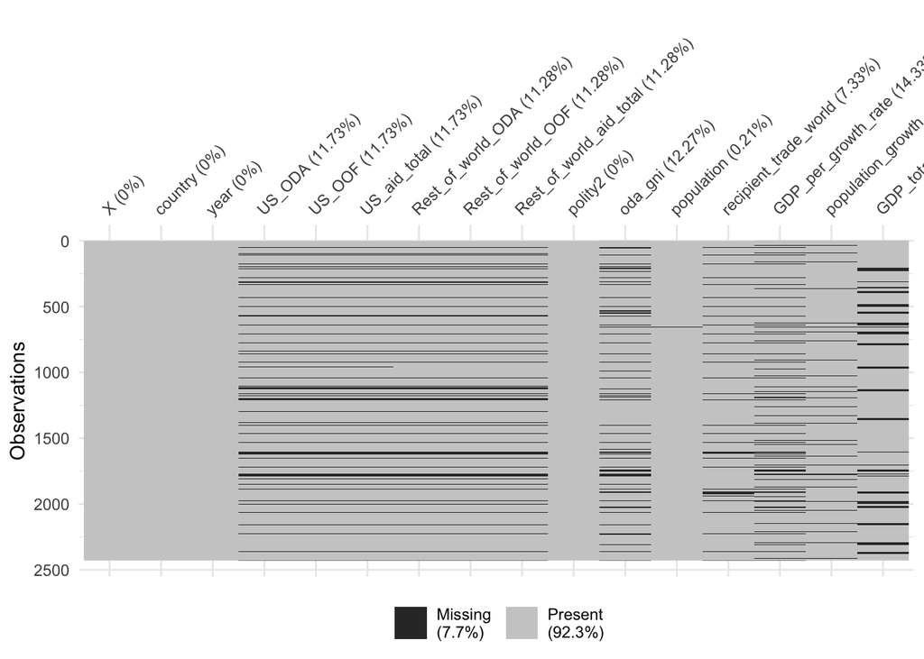

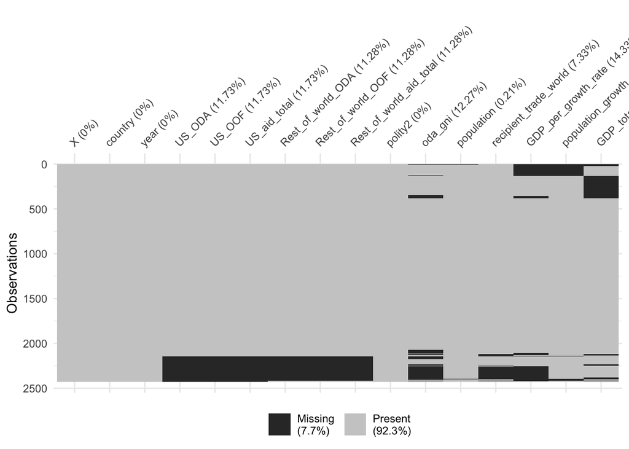

To get away with the time correlated concern, we decide to base our analysis on 2007 and 2012 because they have the least missing data. We conduct analysis on one of them, and use the result of the other one to compare, which serves as a part of sensitive analysis to test the robustness of the former.

```r
aid = aid %>%
  na.omit(aid)

aid2007 = aid %>%
  filter(year==2007)

aid2012 = aid %>%
  filter(year==2012)
```

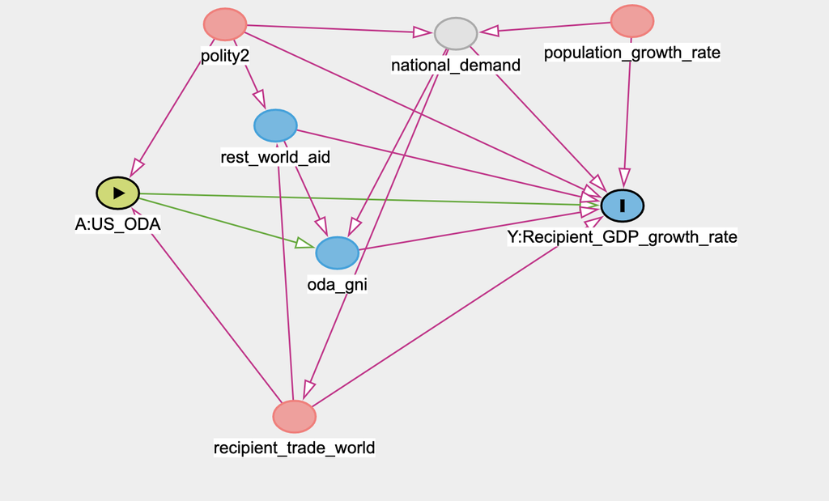

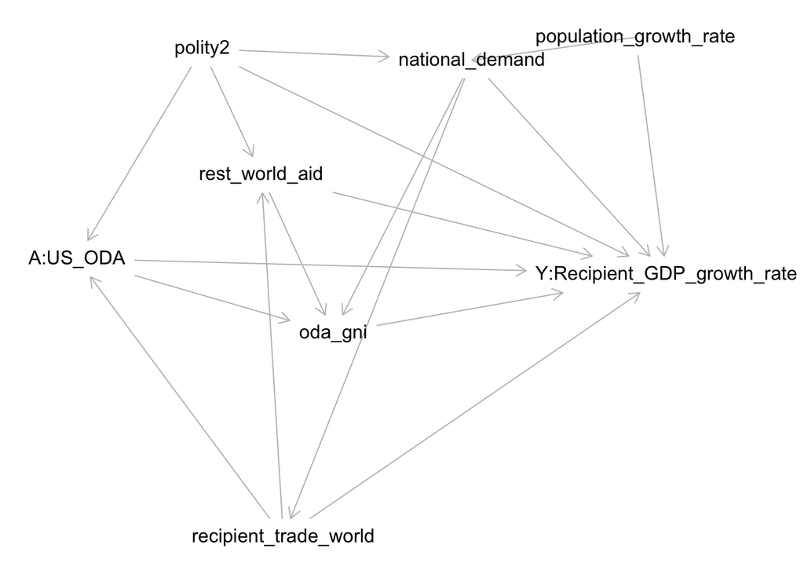

The causal graph is constructed based on our prior assumptions and common sense:

1. The outcome(Y: GDP growth rate of the recipient) depends on the national demand, population growth rate, the foreign aid received, potentially its autocracy-democracy index(polity2), and the recipient’s openness (measured by its global trade).
2. We assume that our treatment, US ODA, affect the outcome via direct effect(the recipient receives the aid) and indirect effect of ODA_GNI. The idea for GNI is that given the same amount of foreign aid, if the aid amounts to a large portion of the recipient’s gross national income, this aid should have a larger impact on the recipient. A similar idea applies to the foreign aid provided by the rest of the world.
3. We assume the recipient country’s openness to global trading contributes to not only GDP growth but also the amount of aid it’s going to receive. The rationale behind the assumption is the potential economic welfare gains from an aid could strongly motivate the donor. For example, the donor might want to have an impact on, or take a share of, the recipient’s market. Finally, we think it’s reasonable to assume that national demand affects the recipient’s global trade.
4. The assumption we made polity2 a confounder that has an impact on a wide range of other variables. The rationale behind this assumption is that the donors might also be motivated by enlarging their political impact on the recipient, such as winning over political support.

# Causal Discovery

The causal graph was constructed based on our prior knowledge, which entails that the relationship assumed could be inaccurate. Therefore, we adopt causal discovery algorithm to generate causal graphs which help us identify causal flows.

The core idea of the algorithm is that if conditional on all possible sets of other variables, there remains a significant relationship between variable A and B, then there exists a direct causal association between them. The direction of the arrow is determined by controlling the middle variable for every three connected variables.

alpha is the threshold for the signifiance level. If

- alpha = 0: holding an extremely high bar for an estimate of ACE to be counted as significant. No edge will be present in the resulted graph.
- alpha = 1: any relationship between nodes is considered to be valid and real. The resulted graph skeleton will be strongly connected.

### alpha = 0.01

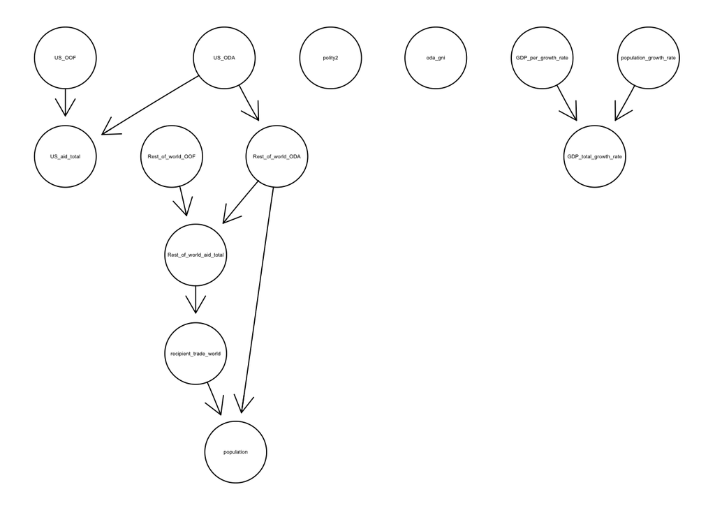

```r
causalAid = aid2012 %>%
  dplyr::select(-X,-country,-year)
suff_stat <- list(C = cor(causalAid), n = nrow(causalAid))
pc_aid <- pc(suff_stat, indepTest = gaussCItest, labels = colnames(causalAid), alpha = 0.01, skel.method = "stable.fast")

plot(pc_aid, main = "")
```

### alpha=0.05

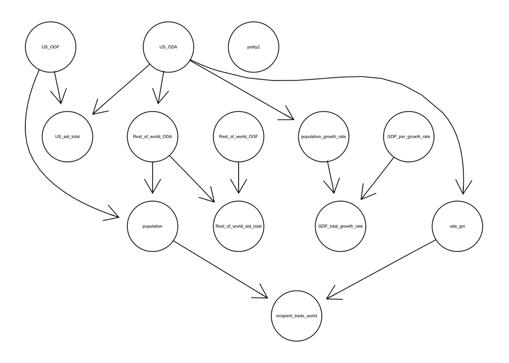

```r
pc_aid <- pc(suff_stat, indepTest = gaussCItest, labels = colnames(causalAid), alpha = 0.05, skel.method = "stable.fast")
plot(pc_aid, main = "")
```

### alpha=0.12

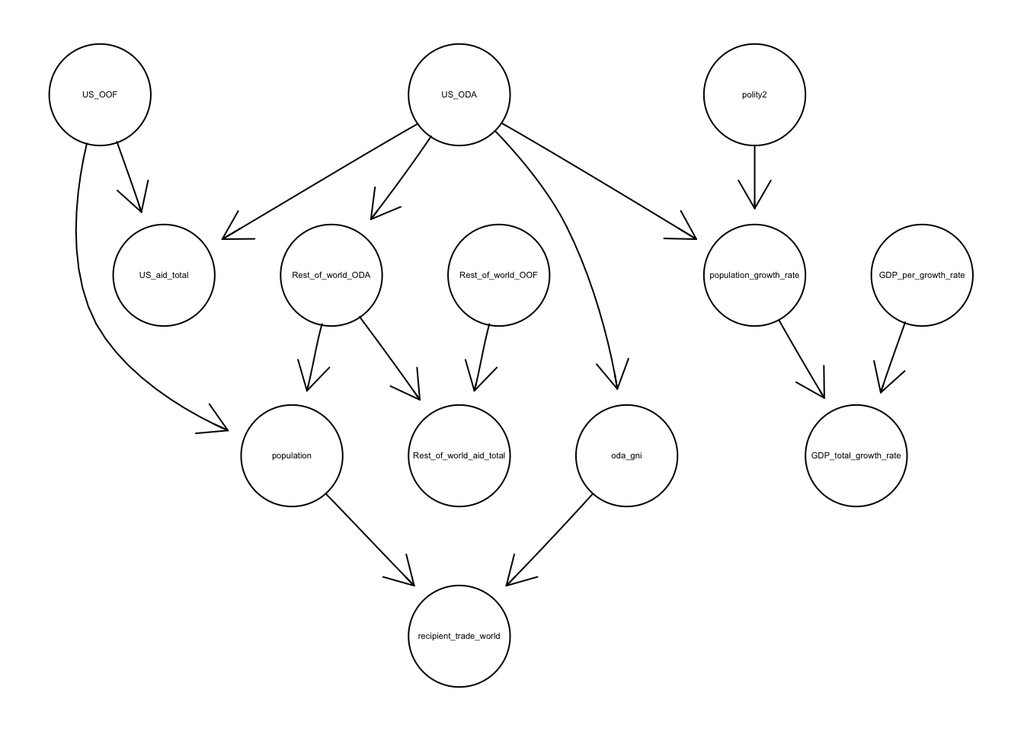

```r
pc_aid <- pc(suff_stat, indepTest = gaussCItest, labels = colnames(causalAid), alpha = 0.12, skel.method = "stable.fast")
plot(pc_aid, main = "")
```

Comparing the resulted causal graph with our assumptions, we spot the following causal flow that we didn’t identify before:

1. it’s mainly ODA, instead of OOF, that contributes to other variables. For example, the graph shows that US_ODA has a direct effect on popolucation growth rate, which stimulates GDP growth. Rest_of_Work_ODA also contributes to population, which directly affects recipient’s world trade.
2. US_ODA has a direct effect on Rest_of_Work_ODA.
3. oda_gni directly affects recipient_trade_world.

As we relax the treshold from 0.01 to 0.12, there are a few changes we think might be of interests:

1. when threshold is 0.01, recipient_trade_world contributes to population. When threshold increases, it’s polulation contributes to recipient_trade_world. Therefore, both directions worth exploring in our later sensitivity analysis.
2. when threshold increases to 0.12, polity2 is considered to contribute to population growth.

It appears that the way variables affect the outcome is via population growth.

# Model Construction informed by causal discovery

Informed by the causal discovery algorithm, we visualize the relationships that are suggested by the causal discovery algorithm in the below section.

We’d like to see

1. Since the generated causal graph suggests `US_ODA` $\rightarrow$ `Rest_of_World_ODA` and no arrow point from `Rest_of_World_ODA` to the outcome, which is counterintuitive. we’d like to see the relationship between `US_ODA`, `Rest_of_World_ODA`, and the growth rate outcome.
2. We were surprised to see the causal graph doesn’t discern a significant causal flow from `Rest_of_World_ODA` to the outcome, so we want to visually check if `Rest_of_World_ODA` is indeed not a mediator, aka if `Rest_of_World_ODA` doesn’t directly contribute to the outcome.
3. When we relax the alpha threshold, we observe that `polity2` and `US_ODA` now both contribute to the outcome. This is consistent with our prior knowledge. Therefore, we want to check if we should introduce interaction term for `polity2` and `US_ODA`. Interaction term means given the same `US_ODA`, if the recipient will have different growth because they have different `polity2`. In other words, if the recipient will react differently towards the same treatment.

##### US_ODA,Rest_of_World_ODA, and GDP_total_growth_rate

How GDP_total_growth_rate is affected by US_ODA and Rest_of_world_ODA?

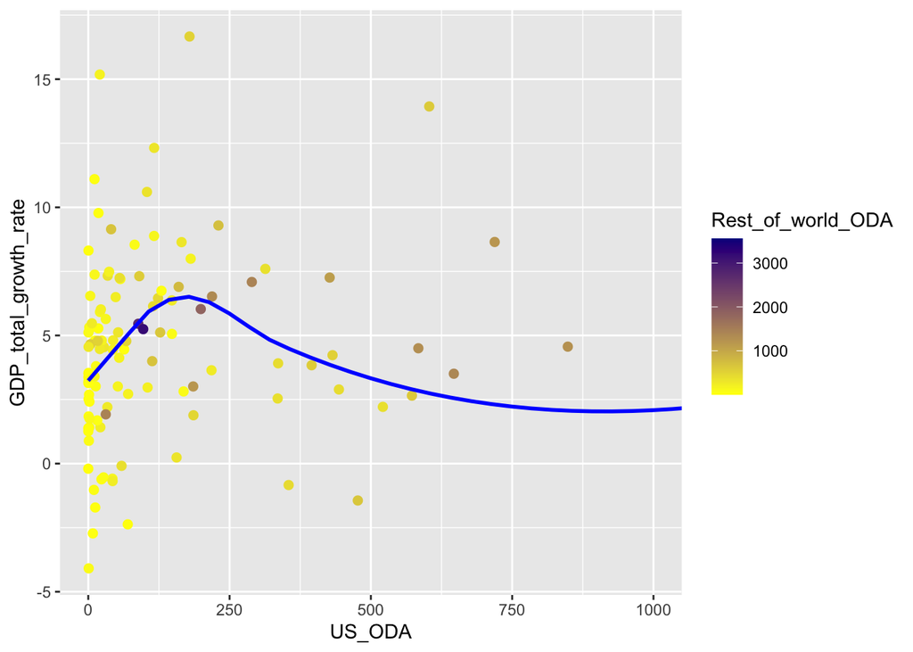

```r
ggplot(data = aid2012, aes(x = US_ODA, y = GDP_total_growth_rate)) +
    geom_point(aes(color = Rest_of_world_ODA), size = 2) +
    geom_smooth(se = FALSE, color = "blue")+
  coord_cartesian(xlim = c(0,1000))+
  scale_color_gradient(low = "yellow", high = "darkblue")
```

Observing the effect of `U.S. ODA`, we can see that there seem to be an increasing trend between 0-250, and another decreasing trend for US_ODA that’s larger than 250. Instead of keep using continuous value for treatment, we decide to cut U.S ODA into two categories: [0,250] and [251,+).

```r
aid2012 <- aid2012%>%
  mutate(US_ODA_C = ifelse(US_ODA<250, 0,1))
```

##### Does Rest_of_world_ODA_total affect the outcome?

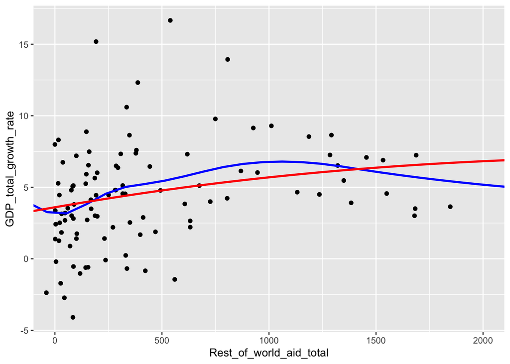

```r
ggplot(data = aid2012, aes(x = Rest_of_world_aid_total, y = GDP_total_growth_rate)) +
    geom_point() +
    geom_smooth(se = FALSE, color = "blue")+
    geom_smooth(formula = y~ns(x,2), method = "lm",
        se = FALSE, color = "red"
    )+
  coord_cartesian(xlim = c(0,2000))
```

Earlier, we didn’t see a causal flow from `rest of world aid` to the outcome, which is implausible from common sense. However, the seemingly positive slope of the bluel line suggests that greater `Rest_of_world_ODA_total` has slightly higher growth rate, although it’s clearly insignificant. However, we are still justified to believe `rest of world aid` *might* open a causal path: `US_ODA` $\rightarrow$ `rest of world aid`$\rightarrow$ `GDP_total_growth_rate`.

##### Does polity2 interact with US_ODA?

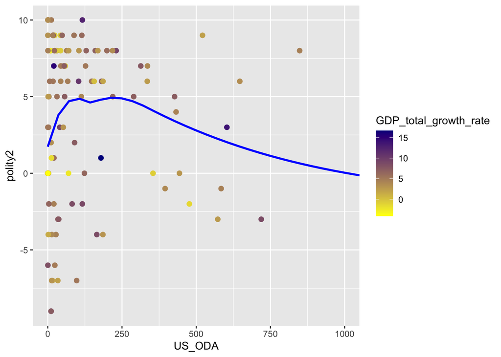

```r
ggplot(data = aid2012, aes(x = US_ODA, y =polity2 )) +
    geom_point(aes(color = GDP_total_growth_rate), size = 2) +
  scale_color_gradient(low = "yellow", high = "darkblue")+
    geom_smooth(se = FALSE, color = "blue")+
  coord_cartesian(xlim = c(0,1000))
```

The colored scatter points don’t seem to form a clear pattern. Therefore we DON’t assume an interaction between polity2 and US_ODA.

## Regression Model

### Regression Results and Interpretation

```r
mod<-lm(GDP_total_growth_rate~ as.factor(US_ODA_C), data = aid2012)
summary(mod)
```

```
##
## Call:
## lm(formula = GDP_total_growth_rate ~ as.factor(US_ODA_C), data = aid2012)
##
## Residuals:
##     Min      1Q  Median      3Q     Max
## -8.5980 -2.1512 -0.0461  2.0177 12.1562
##
## Coefficients:
##                      Estimate Std. Error t value Pr(>|t|)
## (Intercept)            4.5092     0.3762  11.987   <2e-16 ***
## as.factor(US_ODA_C)1   0.4825     0.9383   0.514    0.608
## ---
## Signif. codes:  0 '***' 0.001 '**' 0.01 '*' 0.05 '.' 0.1 ' ' 1
##
## Residual standard error: 3.647 on 110 degrees of freedom
## Multiple R-squared:  0.002398,   Adjusted R-squared:  -0.006671
## F-statistic: 0.2644 on 1 and 110 DF,  p-value: 0.6081
```

```r
confint(mod)
```

```
##                          2.5 %   97.5 %
## (Intercept)           3.763770 5.254699
## as.factor(US_ODA_C)1 -1.377036 2.341995
```

```r
mod1 <- lm(GDP_total_growth_rate~ as.factor(US_ODA_C) +recipient_trade_world+polity2+population_growth_rate,data = aid2012)
summary(mod1)
```

```
##
## Call:
## lm(formula = GDP_total_growth_rate ~ as.factor(US_ODA_C) + recipient_trade_world +
##     polity2 + population_growth_rate, data = aid2012)
##
## Residuals:
##     Min      1Q  Median      3Q     Max
## -7.6338 -2.0881 -0.2703  1.9293 11.4664
##
## Coefficients:
##                          Estimate Std. Error t value Pr(>|t|)
## (Intercept)             2.591e+00  6.847e-01   3.785 0.000254 ***
## as.factor(US_ODA_C)1   -1.153e+00  9.897e-01  -1.165 0.246490
## recipient_trade_world   1.946e-06  2.420e-06   0.804 0.423023
## polity2                -7.298e-03  6.623e-02  -0.110 0.912462
## population_growth_rate  1.179e+02  3.119e+01   3.780 0.000258 ***
## ---
## Signif. codes:  0 '***' 0.001 '**' 0.01 '*' 0.05 '.' 0.1 ' ' 1
##
## Residual standard error: 3.465 on 107 degrees of freedom
## Multiple R-squared:  0.1239, Adjusted R-squared:  0.09111
## F-statistic: 3.782 on 4 and 107 DF,  p-value: 0.006456
```

```r
confint(mod1)
```

```
##                                2.5 %       97.5 %
## (Intercept)             1.233947e+00 3.948641e+00
## as.factor(US_ODA_C)1   -3.115133e+00 8.086383e-01
## recipient_trade_world  -2.850915e-06 6.743434e-06
## polity2                -1.385867e-01 1.239908e-01
## population_growth_rate  5.607653e+01 1.797507e+02
```

### Evaluation of regression model

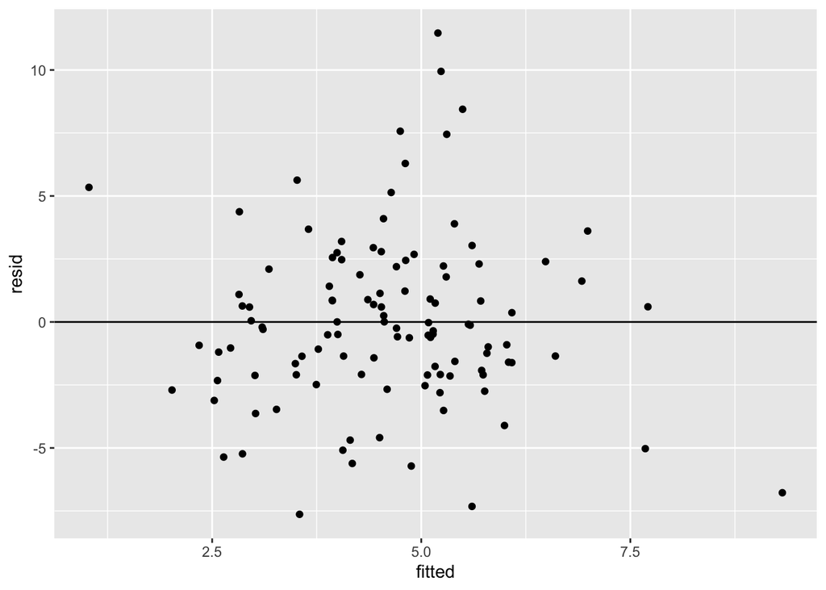

```r
results <- data.frame(resid = resid(mod1), fitted = fitted(mod1))
        ggplot(results, aes(x = fitted, y = resid)) +
          geom_point() +
          geom_hline(yintercept = 0)
```

In the residual plot, we can see that the residuals are assigned relatively evenly across the x-axis; also, the spread is also relatively random. Therefore, we can be confident that there is no heteroskedasticity in our model.

# Sensivity Analysis

## Another Treatment variable

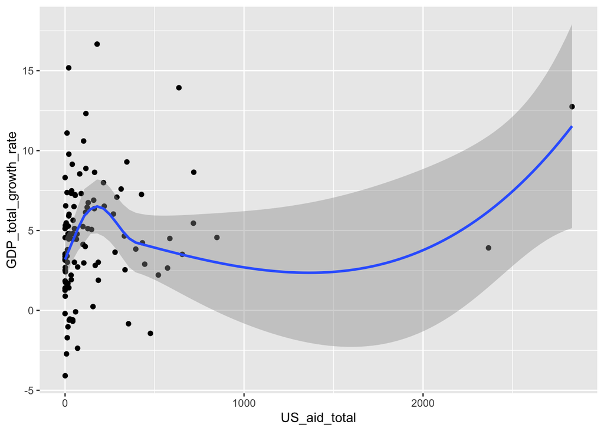

```r
ggplot(data = aid2012, aes(x = US_aid_total, y = GDP_total_growth_rate))+
  geom_point()+
  geom_smooth()
```

According to the graph, we might still want to cut the U.S aid total at around 250 because there is an increasing trend between 0 and 250.

```r
aid2012 <- aid2012%>%
  mutate(US_aid_total_C = ifelse(US_aid_total<250, 0,1))
```

##### 1. Population growth rate vs. U.S aid

```r
p1 <- ggplot(data = aid2012, aes(x = population_growth_rate, y = US_aid_total_C )) +
  geom_point() +
  geom_smooth(se = FALSE, color = "blue")+
  geom_smooth(formula = y~ns(x,3), method = "glm",
    method.args = list(family="binomial"),
    se = FALSE, color = "red" )
```

According to the graph above, we might incorporate population growth rate as an non-linear variable in our model.

##### 2. Trade balance of recipient countries vs. U.S aid

```r
p2 <- ggplot(data = aid2012, aes(x =recipient_trade_world, y = US_aid_total_C )) +
  geom_point() +
  geom_smooth(se = FALSE, color = "blue")+
  geom_smooth(formula = y~ns(x,1), method = "glm",
    method.args = list(family="binomial"),
    se = FALSE, color = "red" )
```

##### 3. Politics score vs. U.S aid

```r
p3 <- ggplot(data = aid2012, aes(x = polity2, y = US_aid_total_C )) +
  geom_point() +
  geom_smooth(se = FALSE, color = "blue")+
  geom_smooth(formula = y~ns(x,3), method = "glm",
    method.args = list(family="binomial"),
    se = FALSE, color = "red" )
```

```r
library("gridExtra")
```

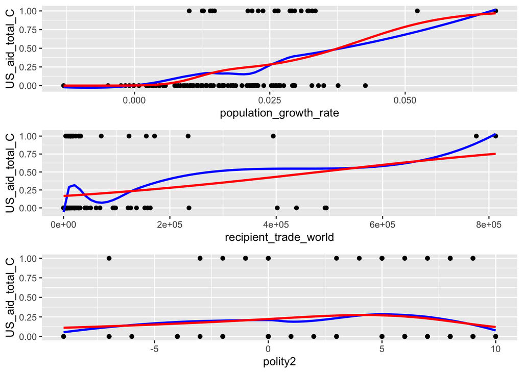

```r
grid.arrange(p1,p2,p3)
```

```r
mod2 <- lm(GDP_total_growth_rate~ as.factor(US_aid_total_C) +recipient_trade_world+ns(polity2,3)+ns(population_growth_rate,3),data = aid2012)
summary(mod2)
```

```
##
## Call:
## lm(formula = GDP_total_growth_rate ~ as.factor(US_aid_total_C) +
##     recipient_trade_world + ns(polity2, 3) + ns(population_growth_rate,
##     3), data = aid2012)
##
## Residuals:
##     Min      1Q  Median      3Q     Max
## -6.8904 -1.9511 -0.3892  1.4876 12.0725
##
## Coefficients:
##                                  Estimate Std. Error t value Pr(>|t|)
## (Intercept)                     4.772e+00  2.612e+00   1.827   0.0706 .
## as.factor(US_aid_total_C)1     -5.983e-01  8.897e-01  -0.672   0.5028
## recipient_trade_world           1.777e-06  2.528e-06   0.703   0.4836
## ns(polity2, 3)1                -9.955e-01  1.419e+00  -0.701   0.4847
## ns(polity2, 3)2                -9.011e+00  3.446e+00  -2.615   0.0103 *
## ns(polity2, 3)3                 1.016e+00  1.097e+00   0.926   0.3566
## ns(population_growth_rate, 3)1  7.881e+00  1.581e+00   4.985 2.51e-06 ***
## ns(population_growth_rate, 3)2  5.136e+00  4.885e+00   1.051   0.2956
## ns(population_growth_rate, 3)3  1.251e+00  3.092e+00   0.405   0.6866
## ---
## Signif. codes:  0 '***' 0.001 '**' 0.01 '*' 0.05 '.' 0.1 ' ' 1
##
## Residual standard error: 3.279 on 103 degrees of freedom
## Multiple R-squared:  0.245,  Adjusted R-squared:  0.1863
## F-statistic: 4.177 on 8 and 103 DF,  p-value: 0.0002334
```

```r
confint(mod2)
```

```
##                                        2.5 %        97.5 %
## (Intercept)                    -4.078245e-01  9.951090e+00
## as.factor(US_aid_total_C)1     -2.362822e+00  1.166267e+00
## recipient_trade_world          -3.236483e-06  6.790932e-06
## ns(polity2, 3)1                -3.810589e+00  1.819567e+00
## ns(polity2, 3)2                -1.584493e+01 -2.176397e+00
## ns(polity2, 3)3                -1.159718e+00  3.190962e+00
## ns(population_growth_rate, 3)1  4.745636e+00  1.101625e+01
## ns(population_growth_rate, 3)2 -4.553221e+00  1.482466e+01
## ns(population_growth_rate, 3)3 -4.880678e+00  7.382384e+00
```

##### 4. Unmeasured Variable

A common robust test is to see how an unmeasured confounder could affect the result. We recognize that the effect of foreign aid on recipient’s economic growth can go through complicated paths, in addition to the ones we showed above. However, due to the lack of data and the complexity of the topic, our causal graph couldn’t capture all the plausible causal relationships. Therefore, we particular need to assume the existence of an unmeasured confounder and see how it would affect our prior result.

Potential unmeasured variables could include recipient’s historical development, recipient’s national diplomacy, the natrual resources the land of the recipient possesses…etc.

First, we need to model the treatment US_ODA_C. To do so, we would first want to visualize the association between U.S aid and other controlled variables. The goal of visualization is to find out if the association is linear or not and if we should introduce the nonlinearity into our model. For all graphs below, blue lines are dervied from the actual data, providing insights on how a variable affects if one receives the treatment or not. The red lines are used to depict that relationship.

Since the absolute value of trade balance of recipient countries is a relative big number compared to the foreign aid, we use the natural log of the trade balance so that we are able to see numbers on the same scale, so our analysis would not be misled by the big numbers. In this graph, we can see that the natural log of trade balance of recipient countries is non-linear.

Similarly, putting population on log scale helps fitting the model.

4.1. US_ODA_C~log(recipient_trade_world)

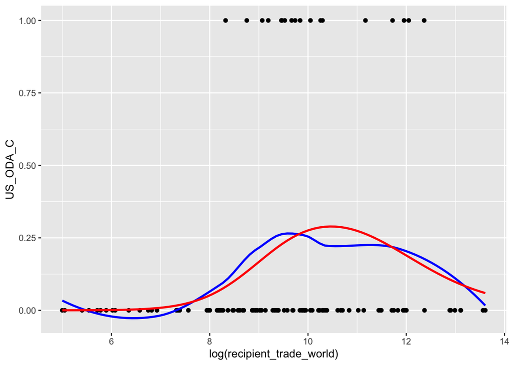

```r
ggplot(data = aid2012, aes(x = log(recipient_trade_world), y = US_ODA_C)) +
  geom_point() +
  geom_smooth(se = FALSE, color = "blue")+
  geom_smooth(formula = y~ns(x,2), method = "glm",
    method.args = list(family="binomial"),
    se = FALSE, color = "red" )
```

4.2. US_ODA_C~polity2

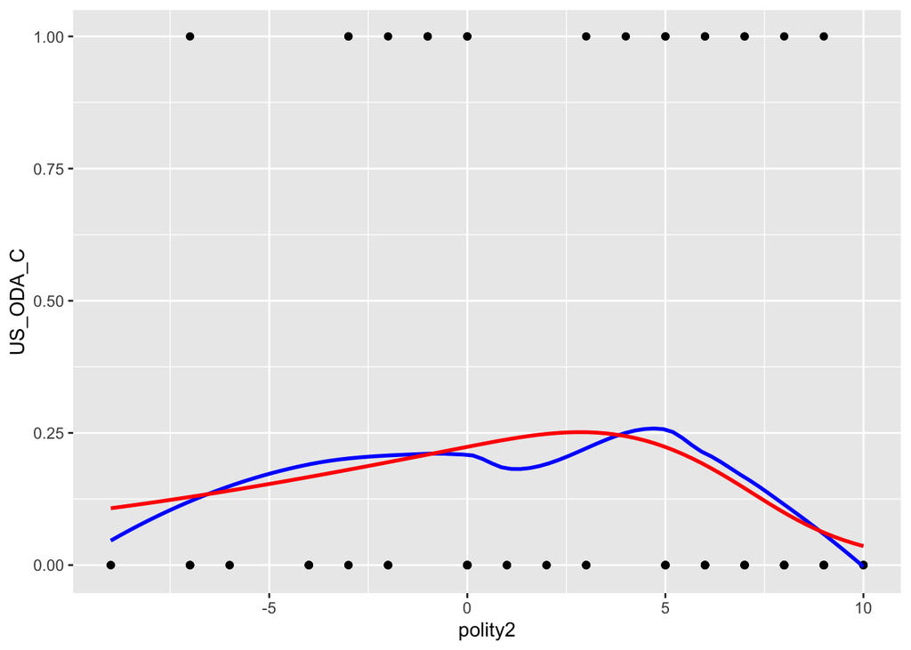

4.3. US_ODA_C~population

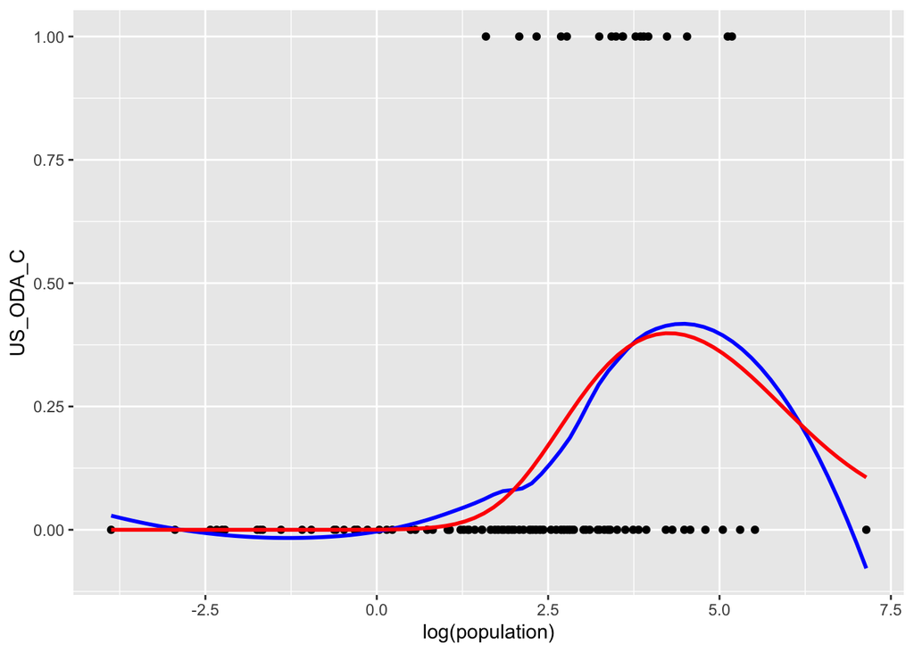

```r
ggplot(data = aid2012, aes(x = log(population), y = US_ODA_C))+
  geom_point() +
  geom_smooth(se = FALSE, color = "blue")+
  geom_smooth(formula = y~ns(x,2), method = "glm",
    method.args = list(family="binomial"),
    se = FALSE, color = "red" )
```

In this graph, we can see that association between U.S ODA and politics score is non-linear; therefore, this variable should also be non-linear in our model

```r
sensitivity_analysis <- function(.data, model_A, model_Y, assoc_A, assoc_Y) {
    n <- nrow(.data)

    # Obtain residuals with residuals()
    # Obtain residual variances with sigma()
    res_A <- residuals(model_A)
    res_var_A <- sigma(model_A)^2
    res_Y <- residuals(model_Y)
    res_var_Y <- sigma(model_Y)^2

    # Compute the mean and variance of U given A and Y
    mean_U_term1 <- (assoc_A/res_var_A)*res_A
    mean_U_term2 <- (((res_var_A - assoc_A^2)*assoc_Y)/(res_var_A*res_var_Y))*res_Y
    mean_U <- mean_U_term1 + mean_U_term2

    var_U_term1 <- (res_var_A - assoc_A^2)/(res_var_A*res_var_Y)
    var_U_term2 <- res_var_Y - assoc_Y^2 + ((assoc_A*assoc_Y)^2)/res_var_A
    var_U <- var_U_term1*var_U_term2

    # Simulate U and add it to the data
    U <- rnorm(n, mean = mean_U, sd = sqrt(var_U))
    .data$U <- U

    ########################################################################
    # The part below is the only part you need to change to implement
    # the sensitivity analysis in a new context.

    # Refit model to estimate the causal effect
    updated_model <- lm(GDP_total_growth_rate~ US_ODA_C +log(recipient_trade_world)+polity2+log(population_growth_rate)+U, data = .data)
    # The names of the coefficients and confidence interval output rows
    # are called "A" for the treatment variable A.
    # This will change in a new dataset.
    list(c(
        estimate = unname(coefficients(updated_model)["US_ODA_C"]),
        ci_95_lower = confint(updated_model)["US_ODA_C",1],
        ci_95_upper = confint(updated_model)["US_ODA_C",2]
    ))
}


# Begin the sensitivity analysis

# Fit required models for the sensitivity analysis
mod_A <- lm(US_ODA_C ~ ns(polity2,3)+ns(log(recipient_trade_world),2)+ns(log(population),2), data = aid2012)
mod_Y <- lm(GDP_total_growth_rate~ US_ODA_C +log(recipient_trade_world)+polity2+log(population_growth_rate), data = aid2012)
summary(mod_A)
```

```
##
## Call:
## lm(formula = US_ODA_C ~ ns(polity2, 3) + ns(log(recipient_trade_world),
##     2) + ns(log(population), 2), data = aid2012)
##
## Residuals:
##      Min       1Q   Median       3Q      Max
## -0.56039 -0.18527 -0.07231  0.04120  0.91509
##
## Coefficients:
##                                    Estimate Std. Error t value Pr(>|t|)
## (Intercept)                         -0.4016     0.2581  -1.556 0.122701
## ns(polity2, 3)1                      0.0832     0.1462   0.569 0.570527
## ns(polity2, 3)2                      0.4664     0.3786   1.232 0.220775
## ns(polity2, 3)3                     -0.1759     0.1120  -1.570 0.119378
## ns(log(recipient_trade_world), 2)1   0.3358     0.4278   0.785 0.434178
## ns(log(recipient_trade_world), 2)2  -0.4180     0.2174  -1.923 0.057171 .
## ns(log(population), 2)1              0.5985     0.5008   1.195 0.234696
## ns(log(population), 2)2              1.0996     0.2937   3.744 0.000298 ***
## ---
## Signif. codes:  0 '***' 0.001 '**' 0.01 '*' 0.05 '.' 0.1 ' ' 1
##
## Residual standard error: 0.3344 on 104 degrees of freedom
## Multiple R-squared:  0.2302, Adjusted R-squared:  0.1784
## F-statistic: 4.442 on 7 and 104 DF,  p-value: 0.0002351
```

```r
summary(mod_Y)
```

```
##
## Call:
## lm(formula = GDP_total_growth_rate ~ US_ODA_C + log(recipient_trade_world) +
##     polity2 + log(population_growth_rate), data = aid2012)
##
## Residuals:
##     Min      1Q  Median      3Q     Max
## -6.4973 -2.0910 -0.2106  1.8263 11.0633
##
## Coefficients:
##                             Estimate Std. Error t value Pr(>|t|)
## (Intercept)                  8.73638    2.57299   3.395 0.000984 ***
## US_ODA_C                    -1.44675    0.92882  -1.558 0.122483
## log(recipient_trade_world)   0.44822    0.17169   2.611 0.010426 *
## polity2                     -0.02564    0.06562  -0.391 0.696791
## log(population_growth_rate)  1.87865    0.47218   3.979 0.000131 ***
## ---
## Signif. codes:  0 '***' 0.001 '**' 0.01 '*' 0.05 '.' 0.1 ' ' 1
##
## Residual standard error: 3.319 on 100 degrees of freedom
##   (7 observations deleted due to missingness)
## Multiple R-squared:  0.1881, Adjusted R-squared:  0.1556
## F-statistic: 5.791 on 4 and 100 DF,  p-value: 0.0003111
```

Since the median residule for mod_A is -0.07231 and for mod_Y is -0.2106, we assume the unmeasure variable should have a positive impact on the outcome.

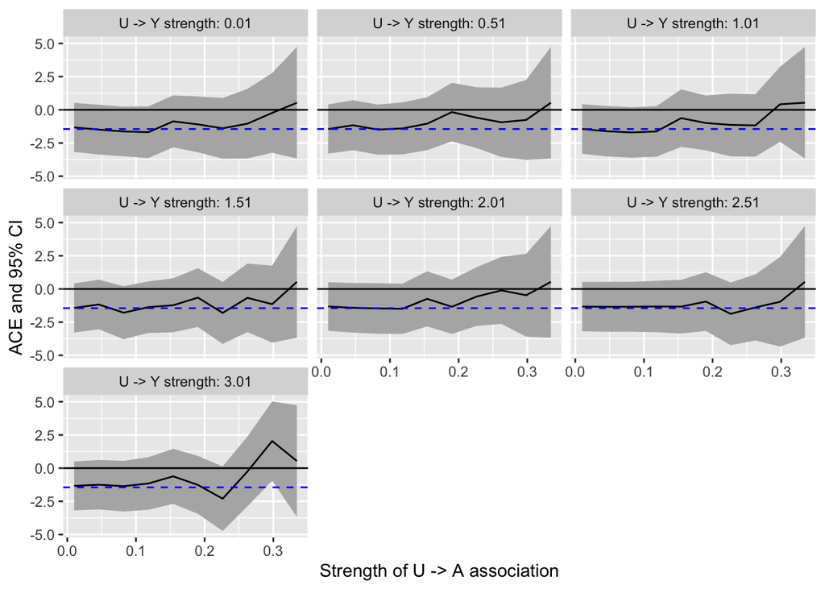

The black line denotes the ACE(US_ODA that’s larger than 250) under the specified U -> Y and U -> A assumption, and the grey in background indicates the range of ACE of the 95% CI. The blue line denotes the original ACE(without taking U into account).

*This is counterintuitive, because usually we would assume more donation results in more obvious economic growth in the recipient’s country. A potential explanation we come up with is that poorer pre-aid condition of the recipient results in more donation, but the donation might not be used effectively due to the poor pre-aid condition. For example, according to prior knowledge, the contries receiving the most aid are Iraq, Jordan, Syria, where the political situation is not very stable. We think this might account for the counterintuitive “more donation –> less ideal” effect.*

Therefore, our estimated ACE is quite robust even after considering a various causal flow that passes U, but insignificant.

##### Different Year (2007)

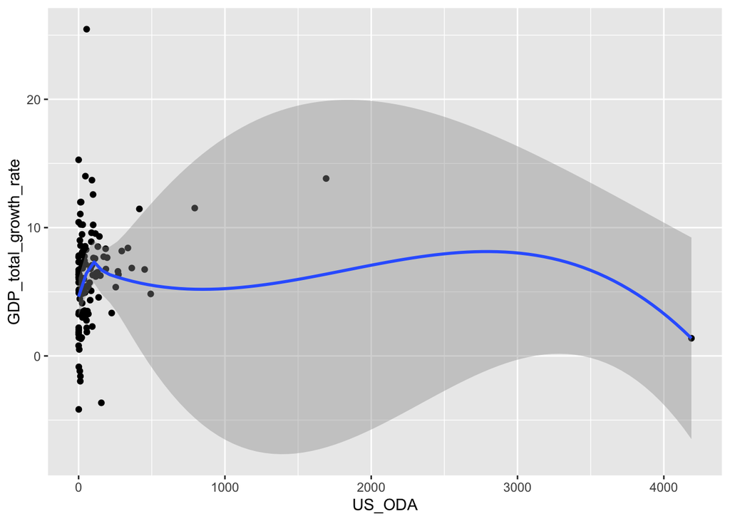

```r
ggplot(data = aid2007, aes(x = US_ODA, y = GDP_total_growth_rate))+
  geom_point()+
  geom_smooth()
```

According to the graph, we might need to cut US_ODA at around 100 because there is an increasing trend before 100.

```r
aid2007 <- aid2007%>%
  mutate(US_ODA_C = ifelse(US_ODA<100, 0,1))
```

###### 1. Population growth rate vs. U.S aid

```r
p4<- ggplot(data = aid2007, aes(x = population_growth_rate, y = US_ODA_C)) +
  geom_point() +
  geom_smooth(se = FALSE, color = "blue")+
  geom_smooth(formula = y~ns(x,3), method = "glm",
    method.args = list(family="binomial"),
    se = FALSE, color = "red" )
```

###### 2. Trade balance of recipient countries vs. U.S aid

```r
p5<- ggplot(data = aid2012, aes(x = recipient_trade_world, y = US_ODA_C)) +
  geom_point() +
  geom_smooth(se = FALSE, color = "blue")+
  geom_smooth(formula = y~ns(x,2), method = "glm",
    method.args = list(family="binomial"),
    se = FALSE, color = "red" )
```

###### 3. Politics score vs. U.S aid

```r
p6<- ggplot(data = aid2012, aes(x = polity2, y = US_ODA_C)) +
  geom_point() +
  geom_smooth(se = FALSE, color = "blue")+
  geom_smooth(formula = y~ns(x,3), method = "glm",
    method.args = list(family="binomial"),
    se = FALSE, color = "red" )
```

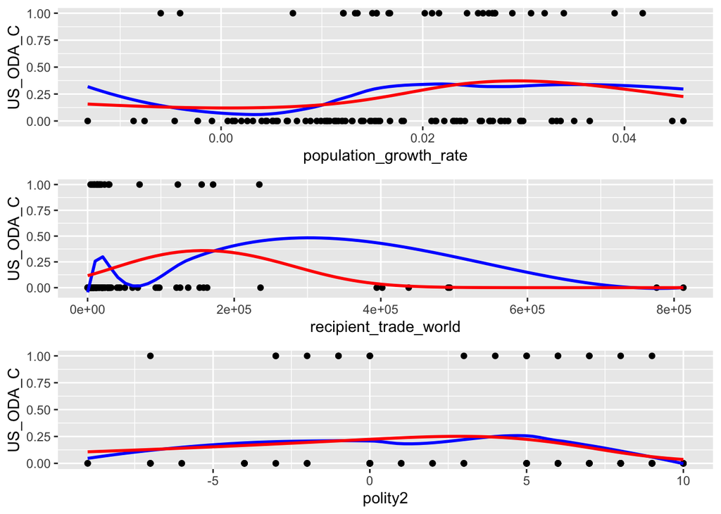

```r
library("gridExtra")
grid.arrange(p4,p5,p6)
```

```r
mod3 <- lm(GDP_total_growth_rate~ as.factor(US_ODA_C) +ns(recipient_trade_world,2)+ns(polity2,3)+ns(population_growth_rate,3),data = aid2007)
summary(mod3)
```

```
##
## Call:
## lm(formula = GDP_total_growth_rate ~ as.factor(US_ODA_C) + ns(recipient_trade_world,
##     2) + ns(polity2, 3) + ns(population_growth_rate, 3), data = aid2007)
##
## Residuals:
##      Min       1Q   Median       3Q      Max
## -10.1962  -1.8888  -0.1496   1.8624  17.7602
##
## Coefficients:
##                                Estimate Std. Error t value Pr(>|t|)
## (Intercept)                     12.3425     2.6334   4.687 8.13e-06 ***
## as.factor(US_ODA_C)1             1.3529     0.9009   1.502   0.1361
## ns(recipient_trade_world, 2)1   -0.2696     2.6707  -0.101   0.9198
## ns(recipient_trade_world, 2)2   -3.9287     3.6745  -1.069   0.2874
## ns(polity2, 3)1                 -2.5519     1.5846  -1.610   0.1102
## ns(polity2, 3)2                -10.3274     3.9478  -2.616   0.0102 *
## ns(polity2, 3)3                  0.4514     1.2467   0.362   0.7180
## ns(population_growth_rate, 3)1  -3.3385     1.6134  -2.069   0.0409 *
## ns(population_growth_rate, 3)2  -2.5303     4.8032  -0.527   0.5994
## ns(population_growth_rate, 3)3   2.3966     2.2263   1.076   0.2841
## ---
## Signif. codes:  0 '***' 0.001 '**' 0.01 '*' 0.05 '.' 0.1 ' ' 1
##
## Residual standard error: 3.847 on 108 degrees of freedom
## Multiple R-squared:  0.138,  Adjusted R-squared:  0.06611
## F-statistic:  1.92 on 9 and 108 DF,  p-value: 0.05641
```

```r
confint(mod3)
```

```
##                                      2.5 %     97.5 %
## (Intercept)                      7.1227420 17.5622559
## as.factor(US_ODA_C)1            -0.4327669  3.1385259
## ns(recipient_trade_world, 2)1   -5.5633919  5.0241182
## ns(recipient_trade_world, 2)2  -11.2121287  3.3547441
## ns(polity2, 3)1                 -5.6928050  0.5889603
## ns(polity2, 3)2                -18.1527452 -2.5021248
## ns(polity2, 3)3                 -2.0198309  2.9226929
## ns(population_growth_rate, 3)1  -6.5366474 -0.1403814
## ns(population_growth_rate, 3)2 -12.0510291  6.9904024
## ns(population_growth_rate, 3)3  -2.0163874  6.8096319
```

It also makes sense that our results differ across different years because the marginal benefit of additional foreign aid is very likely to be different. Since the marginal benefit can differ, then the estimated contribution to the economics should also be different for each year.

##### Another Measurement of Economic growth

```r
mod4 <- lm(GDP_per_growth_rate ~ as.factor(US_ODA_C) +ns(recipient_trade_world,2)+ns(polity2,3)+ns(population_growth_rate,3),data = aid2012)
summary(mod4)
```

```
##
## Call:
## lm(formula = GDP_per_growth_rate ~ as.factor(US_ODA_C) + ns(recipient_trade_world,
##     2) + ns(polity2, 3) + ns(population_growth_rate, 3), data = aid2012)
##
## Residuals:
##      Min       1Q   Median       3Q      Max
## -0.38466 -0.02828  0.00571  0.04298  0.18904
##
## Coefficients:
##                                Estimate Std. Error t value Pr(>|t|)
## (Intercept)                     0.03587    0.06196   0.579    0.564
## as.factor(US_ODA_C)1            0.06030    0.02299   2.623    0.010 *
## ns(recipient_trade_world, 2)1  -0.01800    0.05618  -0.320    0.749
## ns(recipient_trade_world, 2)2  -0.05287    0.06021  -0.878    0.382
## ns(polity2, 3)1                -0.04232    0.03343  -1.266    0.208
## ns(polity2, 3)2                -0.12812    0.08273  -1.549    0.125
## ns(polity2, 3)3                -0.01457    0.02588  -0.563    0.575
## ns(population_growth_rate, 3)1 -0.01183    0.03705  -0.319    0.750
## ns(population_growth_rate, 3)2  0.02024    0.11522   0.176    0.861
## ns(population_growth_rate, 3)3 -0.09129    0.07362  -1.240    0.218
## ---
## Signif. codes:  0 '***' 0.001 '**' 0.01 '*' 0.05 '.' 0.1 ' ' 1
##
## Residual standard error: 0.07729 on 102 degrees of freedom
## Multiple R-squared:  0.1087, Adjusted R-squared:  0.03003
## F-statistic: 1.382 on 9 and 102 DF,  p-value: 0.2061
```

```r
confint(mod4)
```

```
##                                      2.5 %     97.5 %
## (Intercept)                    -0.08702349 0.15875775
## as.factor(US_ODA_C)1            0.01470613 0.10589796
## ns(recipient_trade_world, 2)1  -0.12943714 0.09342922
## ns(recipient_trade_world, 2)2  -0.17230436 0.06656581
## ns(polity2, 3)1                -0.10862235 0.02398517
## ns(polity2, 3)2                -0.29221121 0.03596384
## ns(polity2, 3)3                -0.06590913 0.03676254
## ns(population_growth_rate, 3)1 -0.08530873 0.06165122
## ns(population_growth_rate, 3)2 -0.20830496 0.24878931
## ns(population_growth_rate, 3)3 -0.23732128 0.05473330
```

# Limitations

## Limited Time line

In our model, we only used data in a particular year, which might not be persuasive or representative enough for us to make strong conclusion on the impact of U.S aid. For the future study, we might want to consider using a panel dataset and a time series model, such as the mixed effect model; then we might be able to generalize our conclusion on the impact of U.S aid.

## Other important variables

We also know that there are various type of foreign aid, ODA and OOF. Also, within ODA and OOF, there are various type of aids as well. Some are goverment grants, and others might be loans. Since there are different forms of foreign aids and their characteristics might generate different impact on the economics of the recipient countries. Therefore, we might also want to examine the impact of various types of foreign aids, which can lead us to an alternative answer.

## Causal Discovery and Regression

We used causal discovery to explore various forms of causal paths and graphs; however, we did not build our regression based on different conditional sets generated through causal discovery. Therefore, for future study, we can have different sets of conditional variables according to causal discovery and build regression models for each of those.

# Reference

1. Official development assistance (ODA) - Net ODA - OECD Data. (n.d.). Retrieved October 18, 2020, from https://data.oecd.org/oda/net-oda.htm